# Adversarial Search: Playing Connect 4

Student Name: Christian Melendez

I have used the following AI tools: None

I understand that my submission needs to be my own work: CM

## Instructions

Total Points: Undegraduates 100, graduate students 110

Complete this notebook and submit it. The notebook needs to be a complete project report with your implementation, documentation including a short discussion of how your implementation works and your design choices, and experimental results (e.g., tables and charts with simulation results) with a short discussion of what they mean. Use the provided notebook cells and insert additional code and markdown cells as needed.

## Introduction

You will implement different versions of agents that play Connect 4:

> "Connect 4 is a two-player connection board game, in which the players choose a color and then take turns dropping colored discs into a seven-column, six-row vertically suspended grid. The pieces fall straight down, occupying the lowest available space within the column. The objective of the game is to be the first to form a horizontal, vertical, or diagonal line of four of one's own discs." (see [Connect Four on Wikipedia](https://en.wikipedia.org/wiki/Connect_Four))

Note that [Connect-4 has been solved](https://en.wikipedia.org/wiki/Connect_Four#Mathematical_solution) in 1988. A connect-4 solver with a discussion of how to solve different parts of the problem can be found here: https://connect4.gamesolver.org/en/

## Task 1: Defining the Search Problem [10 point]

Define the components of the search problem:

- Initial state
- Actions
- Transition model (result function)
- Goal state (terminal state and utility)

Initial state: An empty board. (Default is 6x7 but you can make boards of different sizes so I am not specificying that here.)

Actions: Drop a disc into a column.

Transition model: R(s,a) -> s'

Goal state: The goal state for each player is to have 4 of their own colored disks aligned in row, column, or diagonal uninterruped but not the other player's.

How big is the state space? Give an estimate and explain it.

The state space is quite large. The normal board which is described in the wikipedia article above has seven columns and six rows. Each position for the discs can exist in 1 of 3 states, either they are empty, red, or yellow. This gives a possible state space of 3^42.

How big is the game tree that minimax search will go through? Give an estimate and explain it.

The tree would have a branching factor of 7 because after every move there are still 7 columns you can drop your disk in (until they start to fill up) so the upper limit would be 7^42.

## Task 2: Game Environment and Random Agent [25 point]

Use a numpy character array as the board.

```python
import numpy as np

def empty_board(shape=(6, 7)):
    return np.full(shape=shape, fill_value=0)

print(empty_board())
```

```
[[0 0 0 0 0 0 0]
 [0 0 0 0 0 0 0]
 [0 0 0 0 0 0 0]
 [0 0 0 0 0 0 0]
 [0 0 0 0 0 0 0]
 [0 0 0 0 0 0 0]]
```

The standard board is $6 \times 7$ but you can use smaller boards to test your code. Instead of colors (red and yellow), I use 1 and -1 to represent the players. Make sure that your agent functions all have the from: `agent_type(board, player = 1)`, where board is the current board position (in the format above) and player is the player whose next move it is and who the agent should play (as 1 and -1).

[figure not shown]

```python
# Visualization code by Randolph Rankin

import matplotlib.pyplot as plt

def visualize(board):
    plt.axes()
    rectangle=plt.Rectangle((-0.5,len(board)*-1+0.5),len(board[0]),len(board),fc='blue')
    circles=[]
    for i,row in enumerate(board):
        for j,val in enumerate(row):
            color='white' if val==0 else 'red' if val==1 else 'yellow'
            circles.append(plt.Circle((j,i*-1),0.4,fc=color))

    plt.gca().add_patch(rectangle)
    for circle in circles:
        plt.gca().add_patch(circle)

    plt.axis('scaled')
    plt.show()

board = [[0, 0, 0, 0, 0, 0, 0],
         [0, 0, 0, 0, 0, 0, 0],
         [0, 0, 0, 0, 0, 0, 0],
         [0, 0, 0, 1, 0, 0, 0],
         [0, 0, 0, 1, 0, 0, 0],
         [0,-1,-1, 1,-1, 0, 0]]
visualize(board)
```

Implement helper functions for:

- A check for available actions in each state `actions(s)`.
- The transition model `result(s, a)`.
- Check for terminal states `terminal(s)`.
- The utility function `utility(s)`.

Make sure that all these functions work with boards of different sizes (number of columns and rows).

```python
# Your code/ answer goes here.
def check_actions(board):
  available_actions = []
  column = 0
  available_actions_iterator = 0
  for i in board[0]:
    if i == 0:
      available_actions.append(column)
    column += 1
  #return available_actions
  for i in available_actions:
    for row in range(len(board), 0, -1):
      if board[row-1][i] == 0:
        available_actions[available_actions_iterator] = [row-1, i]
        break
    available_actions_iterator += 1

  return available_actions
```

```python
def result(state, player, action_row, action_column):
    """Add move to the board."""
    #make a copy first
    state = np.copy(state)

    #check if the action is legal
    if(state[action_row, action_column] != 0):
        print("Error: Illegal move!")


    # Note: x.copy() makes a deep copy of a Python list. For a numpy array/matrix you
    #       need to use numpy.copy() instead!
    state[action_row, action_column] = player

    return state
```

```python
def other(player):
    if player == 1: return -1
    else: return 1
```

```python
def check_horizontal_win(board, row, column):
  if len(board[0]) - column < 4:
    return False
  number_to_check = board[row][column]
  total_consecutive_discs = 1
  for i in range(column + 1, len(board[0])):
    if board[row][i] == number_to_check:
      total_consecutive_discs += 1
      if total_consecutive_discs == 4:
        return True
    else: return False
```

```python
def check_vertical_win(board, row, column):
  if len(board) - row < 4:
    return False
  number_to_check = board[row][column]
  total_consecutive_discs = 1
  for i in range(row + 1, len(board)):
    if board[i][column] == number_to_check:
      total_consecutive_discs += 1
      if total_consecutive_discs == 4:
        return True
    else: return False
```

```python
def check_diagonal_win(board, row, column):
  if len(board[0]) - column < 4:
    return False
  number_to_check = board[row][column]
  total_consecutive_discs = 1
  if len(board) - row > 3:
    for i in range(1, 4):
      if board[row + i][column + i] == number_to_check:
        total_consecutive_discs += 1
        if total_consecutive_discs == 4:
          return True
  if row > 2:
    total_consecutive_discs = 1
    for i in range(1, 4):
      if board[row - i][column + i] == number_to_check:
        total_consecutive_discs += 1
        if total_consecutive_discs == 4:
          return True
  return False
```

```python
def terminal_checks(board):
  '''check the board and return -1, 1, d (draw), or n for next move'''
  non_full_columns = check_actions(board)
  win_check = False
  for row in range(len(board)):
    for column in range(len(board[0])):
      if board[row][column] != 0:
        winner = board[row][column]
        win_check = check_horizontal_win(board, row, column)
        if win_check:
          return winner
        win_check = check_vertical_win(board, row, column)
        if win_check:
          return winner
        win_check = check_diagonal_win(board, row, column)
        if win_check:
          return winner
  if len(non_full_columns) == 0:
    return 'd'
  return 'n'
```

```python
def utility(state, player):
  if player not in [-1, 1]:
    print("Error: Player must be -1 or 1")
    return None
  goal = terminal_checks(state)
  if goal == player: return +1
  if goal == 'd': return 0
  if goal == other(player): return -1
  return None
```

Implement an agent that plays randomly. Make sure the agent function receives as the percept the board and returns a valid action. Use an agent function definition with the following signature (arguments):

`def random_player(board, player = 1): ...`

The argument `player` is used for agents that do not store what color they are playing. The value passed on by the environment should be 1 ot -1 for player red and yellow, respectively. See [Experiments section for tic-tac-toe](https://nbviewer.org/github/mhahsler/CS7320-AI/blob/master/Games/tictactoe_and_or_tree_search.ipynb#Experiments) for an example.

```python
# Your code/ answer goes here.
import random

def random_player(board, player = 1):
  actions = check_actions(board)
  random_selector = random.randint(0, len(actions) - 1)
  return actions[random_selector]

class Random_Agent:
    def __init__(self, initial_state, player , name = "An Agent"):
        self.state = initial_state # this is the state of the agent
        self.player = player
        self.name = name

    def act(self, state):
        #print("    ", self.name, ": My state is", self.state, "and I am going to make a move.")

        action = random_player(state, player = 1)
        self.state = result(state, self.player, action[0], action[1])

        print("    ", self.name, ": I play move [", action[0], "", action[1], "].")

        return action
```

Let two random agents play against each other 1000 times. Look at the [Experiments section for tic-tac-toe](https://nbviewer.org/github/mhahsler/CS7320-AI/blob/master/Games/tictactoe_and_or_tree_search.ipynb#Experiments) to see how the environment uses the agent functions to play against each other.

How often does each player win? Is the result expected?

```python
# Your code/ answer goes here.
def switch_player(player):
  if player == -1:
    return 1
  else:
    return -1

def play(N = 1000):
  results = {-1: 0, 1: 0, 'd': 0}

  for i in range(N):
    board = empty_board()
    active_player = 1
    while True:
      action = random_player(board, active_player)
      board = result(board, active_player, action[0], action[1])

      win = terminal_checks(board)
      if win != 'n':
        results[win] += 1
        break

      active_player = switch_player(active_player)
  return results
```

```python
%time display(play())
```

```
{-1: 445, 1: 552, 'd': 3}
```

```
CPU times: user 2.42 s, sys: 121 ms, total: 2.54 s
Wall time: 2.47 s
```

It looks like the player who goes first tends to win more often. Also, draws are rare.

## Task 3: Minimax Search with Alpha-Beta Pruning

### Implement the Search [20 points]

Implement minimax search starting from a given board for specifying the player. You can use code from the [tic-tac-toe example](https://nbviewer.org/github/mhahsler/CS7320-AI/blob/master/Games/tictactoe_alpha_beta_tree_search.ipynb).

**Important Notes:**

- Make sure that all your agent functions have a signature consistent with the random agent above and that it [uses a class to store state information.](https://nbviewer.org/github/mhahsler/CS7320-AI/blob/master/HOWTOs/store_agent_state_information.ipynb) This is essential to be able play against agents from other students later.
- The search space for a $6 \times 7$ board is large. You can experiment with smaller boards (the smallest is $4 \times 4$) and/or changing the winning rule to connect 3 instead of 4.

```python
# global variables
DEBUG = 1 # 1 ... count nodes, 2 ... debug each node
COUNT = 0

def alpha_beta_search(board, player = 1):
    """start the search."""
    global DEBUG, COUNT
    COUNT = 0

    value, move = max_value_ab(board, player, -math.inf, +math.inf)

    if DEBUG >= 1: print(f"Number of nodes searched: {COUNT}")

    return { "move": move, "value": value }

def max_value_ab(state, player, alpha, beta):
    """player's best move."""
    global DEBUG, COUNT
    COUNT += 1

    # return utility of state is a terminal state
    v = utility(state, player)
    if DEBUG >= 2: print(f"max: {state} [alpha,beta]=[{alpha},{beta}] v={v}")
    if v is not None:
        if DEBUG >= 2: print(f"     found terminal state. backtracking.")
        return v, None

    v, move = -math.inf, None

    # check all possible actions in the state, update alpha and return move with the largest value
    for a in check_actions(state):
        v2, a2 = min_value_ab(result(state, player, a[0], a[1]), player, alpha, beta)
        if DEBUG >= 2: print(f"max: {state} (backtracked) [alpha,beta]=[{alpha},{beta}] v={v2}")

        if v2 > v:
            v, move = v2, a
            alpha = max(alpha, v)
        if v >= beta:
            if DEBUG >= 2: print(f"     v>=beta ({v}>={beta}): pruning remaining subtree (actions). backtracking.")
            return v, move

    return v, move

def min_value_ab(state, player, alpha, beta):
    """opponent's best response."""
    global DEBUG, COUNT
    COUNT += 1

    # return utility of state is a terminal state
    v = utility(state, player)
    if DEBUG >= 2: print(f"min: {state} [alpha,beta]=[{alpha},{beta}] v={v}")
    if v is not None:
        if DEBUG >= 2: print(f"     found terminal state. backtacking.")
        return v, None

    v, move = +math.inf, None

    # check all possible actions in the state, update beta and return move with the smallest value
    for a in check_actions(state):
        v2, a2 = max_value_ab(result(state, other(player), a[0], a[1]), player, alpha, beta)
        if DEBUG >= 2: print(f"min: {state} (backtracked) [alpha,beta]=[{alpha},{beta}] v={v2}")

        if v2 < v:
            v, move = v2, a
            beta = min(beta, v)
        if v <= alpha:
            if DEBUG >= 2: print(f"     v<=alpha ({v}<={alpha}): pruning remaining subtree (actions). backtracking.")
            return v, move

    return v, move
```

```python
class Agent:
    def __init__(self, initial_state, player , name = "An Agent"):
        self.state = initial_state # this is the state of the agent
        self.player = player
        self.name = name

    def act(self, state):
        #print("    ", self.name, ": My state is", self.state, "and I am going to make a move.")

        action = alpha_beta_search(state, self.player)
        self.state = result(state, self.player, action['move'][0], action['move'][1])

        print("    ", self.name, ": I play move [", action['move'][0], "", action['move'][1], "].")

        return action
```

```python
agent_red = Agent(board, 1, name = 'red agent')
```

```python
def agent_play(N = 1000, board=empty_board(shape=(4,4))):
  results = {-1: 0, 1: 0, 'd': 0}

  for i in range(N):
    #board = empty_board(shape=(4,4))
    agent_red = Agent(board, 1, name = 'red agent')
    agent_yellow = Agent(board, -1, name = 'yellow agent')
    active_player = agent_red
    while True:
      action = active_player.act(board)
      board = result(board, active_player.player, action['move'][0], action['move'][1])

      win = terminal_checks(board)
      if win != 'n':
        results[win] += 1
        break

      if active_player.player == 1:
        active_player = agent_yellow
      else:
        active_player = agent_red
  return results
```

```python
%time display(agent_play(N=1))
```

```
Number of nodes searched: 62889
     red agent : I play move [ 3  0 ].
Number of nodes searched: 32379
     yellow agent : I play move [ 2  0 ].
Number of nodes searched: 27522
     red agent : I play move [ 1  0 ].
Number of nodes searched: 10597
     yellow agent : I play move [ 0  0 ].
Number of nodes searched: 2463
     red agent : I play move [ 3  1 ].
Number of nodes searched: 1439
     yellow agent : I play move [ 2  1 ].
Number of nodes searched: 811
     red agent : I play move [ 1  1 ].
Number of nodes searched: 314
     yellow agent : I play move [ 0  1 ].
Number of nodes searched: 91
     red agent : I play move [ 3  2 ].
Number of nodes searched: 50
     yellow agent : I play move [ 3  3 ].
Number of nodes searched: 33
     red agent : I play move [ 2  2 ].
Number of nodes searched: 16
     yellow agent : I play move [ 1  2 ].
Number of nodes searched: 9
     red agent : I play move [ 0  2 ].
Number of nodes searched: 4
     yellow agent : I play move [ 2  3 ].
Number of nodes searched: 3
     red agent : I play move [ 1  3 ].
Number of nodes searched: 2
     yellow agent : I play move [ 0  3 ].
```

```
{-1: 0, 1: 0, 'd': 1}
```

```
CPU times: user 9.78 s, sys: 430 ms, total: 10.2 s
Wall time: 10.1 s
```

Experiment with some manually created boards (at least 5) to check if the agent spots winning opportunities.

```python
board1 = [[0, 0, 0, 0],
         [0, 0, 0, 0],
         [0, 0, 0, -1],
         [0, 1, 1, 1]]
```

```python
# Your code/ answer goes here.
%time display(agent_play(N=1, board = board1))
```

```
Number of nodes searched: 1194
     red agent : I play move [ 3  0 ].
```

```
{-1: 0, 1: 1, 'd': 0}
```

```
CPU times: user 101 ms, sys: 3.06 ms, total: 104 ms
Wall time: 105 ms
```

```python
board2 = [[0, 0, 0, 0],
         [-1, 1, 1, 1],
         [-1, -1, 1, -1],
         [-1, 1, -1, 1]]
```

```python
%time display(agent_play(N=1, board = board2))
```

```
Number of nodes searched: 8
     red agent : I play move [ 0  0 ].
```

```
{-1: 0, 1: 1, 'd': 0}
```

```
CPU times: user 11.9 ms, sys: 1 ms, total: 12.9 ms
Wall time: 15.2 ms
```

```python
board3 = [[0, 0, 0, 0, 1],
         [1, 0, 0, -1, 1],
         [-1, -1, 1, -1, -1],
         [1, -1, 1, -1, 1],
         [-1, -1, -1, 1, -1]]
```

```python
%time display(agent_play(N=1, board = board3))
```

```
Number of nodes searched: 141
     red agent : I play move [ 0  0 ].
Number of nodes searched: 12
     yellow agent : I play move [ 1  1 ].
```

```
{-1: 1, 1: 0, 'd': 0}
```

```
CPU times: user 24.8 ms, sys: 3.04 ms, total: 27.8 ms
Wall time: 29.6 ms
```

```python
board4 = [[0, 0, 0, 0, 1],
         [1, 0, 0, -1, 1],
         [-1, -1, 1, -1, -1],
         [1, -1, 1, -1, 1],
         [-1, -1, 1, 1, -1],
         [1, 1, -1, -1, 1],
         [-1, -1, 1, 1, 1],
         [1, 1, -1, -1, -1],
         [-1, -1, 1, 1, 1]]
```

```python
%time display(agent_play(N=1, board = board4))
```

```
Number of nodes searched: 92
     red agent : I play move [ 1  2 ].
```

```
{-1: 0, 1: 1, 'd': 0}
```

```
CPU times: user 27.8 ms, sys: 931 µs, total: 28.7 ms
Wall time: 32.9 ms
```

```python
board5 = [[0, 0, 0, 0, 1, 0, 0, 0, 0, 1],
         [1, 0, 0, -1, -1, 1, 0, 0, -1, 1],
         [-1, -1, 1, -1, 1, -1, -1, 1, -1, -1],
         [1, -1, 1, -1, 1, 1, -1, 1, -1, 1]]
```

```python
%time display(agent_play(N=1, board = board5))
```

```
Number of nodes searched: 47938
     red agent : I play move [ 0  0 ].
Number of nodes searched: 818
     yellow agent : I play move [ 1  1 ].
Number of nodes searched: 101
     red agent : I play move [ 0  1 ].
Number of nodes searched: 88
     yellow agent : I play move [ 1  2 ].
```

```
{-1: 1, 1: 0, 'd': 0}
```

```
CPU times: user 7.96 s, sys: 274 ms, total: 8.23 s
Wall time: 8.74 s
```

How long does it take to make a move? Start with a smaller board with 4 columns and make the board larger by adding columns.

```python
# Your code/ answer goes here.
board4x4 = empty_board(shape=(4,4))
agent_red = Agent(board4x4, 1, name = 'red agent')
%time display(agent_red.act(board4x4))
```

```
Number of nodes searched: 62889
     red agent : I play move [ 3  0 ].
```

```
{'move': [3, 0], 'value': 0}
```

```
CPU times: user 4.7 s, sys: 309 ms, total: 5.01 s
Wall time: 4.84 s
```

```python
board4x5 = empty_board(shape=(4,5))
agent_red = Agent(board4x5, 1, name = 'red agent')
%time display(agent_red.act(board4x5))
```

```
Number of nodes searched: 18026614
     red agent : I play move [ 3  1 ].
```

```
{'move': [3, 1], 'value': 0}
```

```
CPU times: user 26min 47s, sys: 1min 7s, total: 27min 54s
Wall time: 27min 18s
```

The jump from a 4x4 to a 4x5 went from 4 seconds to 27 minutes so I'm not going to go any further.

### Move ordering [5 points]

Starting the search with better moves will increase the efficiency of alpha-beta pruning. Describe and implement a simple move ordering strategy. Make a table that shows how the ordering strategies influence the time it takes to make a move?

I have chosen to implement move ordering that prioritizes the middle of the board since those squares are connected to more squares.

```python
# Your code/ answer goes here.
def check_actions(board):
  available_actions = []
  column = 0
  available_actions_iterator = 0
  priority = []
  insert = 0
  for i in board[0]:
    if i == 0:
      available_actions.append(column)
    column += 1

  for i in range(len(board)):
    priority.append(insert)
    if len(board) % 2 == 1:
        if i < len(board) / 2 - 1:
            insert +=1
        else:
            insert -=1
    else:
        if i < len(board) / 2 - 1:
            insert +=1
        elif i == len(board) / 2 - 1:
            continue
        else:
            insert -=1
  #priority = [priority[i] for i in available_actions]
  available_actions = [a for _,a in sorted(zip(priority, available_actions), reverse = True)]

  #return available_actions
  for i in available_actions:
    for row in range(len(board), 0, -1):
      if board[row-1][i] == 0:
        available_actions[available_actions_iterator] = [row-1, i]
        break
    available_actions_iterator += 1
  #priority = [priority[i] for i in available_actions]
  #available_actions = [a for _,a in sorted(zip(priority, available_actions), reverse = True)]
  return available_actions
```

```python
board = empty_board()
check_actions(board)
```

```
[[5, 3], [5, 2], [5, 4], [5, 1], [5, 5], [5, 0]]
```

### The first few moves [5 points]

Start with an empty board. This is the worst case scenario for minimax search since it needs solve all possible games that can be played (minus some pruning) before making the decision. What can you do?

```python
# Your code/ answer goes here.
board4x4 = empty_board(shape=(4,4))
agent_red = Agent(board4x4, 1, name = 'red agent')
%time display(agent_red.act(board4x4))
```

```
Number of nodes searched: 155536
     red agent : I play move [ 3  2 ].
```

```
{'move': [3, 2], 'value': 0}
```

```
CPU times: user 11.3 s, sys: 533 ms, total: 11.8 s
Wall time: 11.6 s
```

```python
%time display(agent_play(N=1))
```

```
Number of nodes searched: 155536
     red agent : I play move [ 3  2 ].
Number of nodes searched: 130291
     yellow agent : I play move [ 2  2 ].
Number of nodes searched: 28940
     red agent : I play move [ 1  2 ].
Number of nodes searched: 13292
     yellow agent : I play move [ 0  2 ].
Number of nodes searched: 2002
     red agent : I play move [ 3  3 ].
Number of nodes searched: 1032
     yellow agent : I play move [ 2  3 ].
Number of nodes searched: 864
     red agent : I play move [ 1  3 ].
Number of nodes searched: 311
     yellow agent : I play move [ 0  3 ].
Number of nodes searched: 91
     red agent : I play move [ 3  1 ].
Number of nodes searched: 50
     yellow agent : I play move [ 3  0 ].
Number of nodes searched: 33
     red agent : I play move [ 2  1 ].
Number of nodes searched: 16
     yellow agent : I play move [ 1  1 ].
Number of nodes searched: 9
     red agent : I play move [ 0  1 ].
Number of nodes searched: 4
     yellow agent : I play move [ 2  0 ].
Number of nodes searched: 3
     red agent : I play move [ 1  0 ].
Number of nodes searched: 2
     yellow agent : I play move [ 0  0 ].
```

```
{-1: 0, 1: 0, 'd': 1}
```

```
CPU times: user 24.6 s, sys: 1.21 s, total: 25.8 s
Wall time: 25.2 s
```

I found that using the move ordering actually made my agent's much slower. Because of this I am going to reset my check_actions function to the original.

```python
# Your code/ answer goes here.
def check_actions(board):
  available_actions = []
  column = 0
  available_actions_iterator = 0
  for i in board[0]:
    if i == 0:
      available_actions.append(column)
    column += 1
  #return available_actions
  for i in available_actions:
    for row in range(len(board), 0, -1):
      if board[row-1][i] == 0:
        available_actions[available_actions_iterator] = [row-1, i]
        break
    available_actions_iterator += 1

  return available_actions
```

### Playtime [5 points]

Let the Minimax Search agent play a random agent on a small board. Analyze wins, losses and draws.

```python
# Your code/ answer goes here.
def agent_play_mini_vs_random(N = 1000, board=empty_board(shape=(4,4))):
  results = {-1: 0, 1: 0, 'd': 0}
  state = np.copy(board)
  for i in range(N):
    board = np.copy(state)
    agent_red = Random_Agent(board, 1, name = 'random red agent')
    agent_yellow = Agent(board, -1, name = 'minimax yellow agent')
    active_player = agent_red
    while True:
      action = active_player.act(board)
      if active_player.player == 1:
        board = result(board, active_player.player, action[0], action[1])
      else:
        board = result(board, active_player.player, action['move'][0], action['move'][1])

      win = terminal_checks(board)
      if win != 'n':
        visualize(board)
        results[win] += 1
        break

      if active_player.player == 1:
        active_player = agent_yellow
      else:
        active_player = agent_red
  return results
```

```python
%time display(agent_play_mini_vs_random(N=100))
```

```
Output hidden; open in https://colab.research.google.com to view.
```

## Task 4: Heuristic Alpha-Beta Tree Search

### Heuristic evaluation function [15 points]

Define and implement a heuristic evaluation function.

```python
def check_horizontal_count(board, row, column):
  number_to_check = board[row][column]
  total_consecutive_discs = 1
  for i in range(column + 1, len(board[0])):
    if board[row][i] == number_to_check:
      total_consecutive_discs += 1
      if total_consecutive_discs == 3 and 0 in board[row]:
        return 1
    else: return 0
  return 0

def check_vertical_count(board, row, column):
  number_to_check = board[row][column]
  total_consecutive_discs = 1
  for i in range(row + 1, len(board)):
    if board[i][column] == number_to_check:
      total_consecutive_discs += 1
      if total_consecutive_discs == 3 and 0 in board[:, column]:
        return 1
    else: return 0
  return 0

def check_diagonal_count(board, row, column):
  if len(board[0]) - column < 4:
    return 0
  number_to_check = board[row][column]
  total_consecutive_discs = 1
  if len(board) - row > 3:
    for i in range(1, 4):
      if board[row + i][column + i] == number_to_check:
        total_consecutive_discs += 1
        if total_consecutive_discs == 3:
          return 1
  if row > 2:
    total_consecutive_discs = 1
    for i in range(1, 4):
      if board[row - i][column + i] == number_to_check:
        total_consecutive_discs += 1
        if total_consecutive_discs == 3:
          return 1
  return 0
```

```python
# Your code/ answer goes here.
def eval_fun(state, player):
    """heuristic for utility of state. Returns score for a node:
    1. For terminal states it returns the utility.
    2. For non-terminal states, it calculates a weighted linear function using features of the state.
    The features we look at are 3 in a row/col/diagonal where there exists a remaining empty slot for discs. We assume that
    the more of these positions we have, the higher the chance of winning.
    We need to be careful that the utility of the heuristic stays between [-1,1].
    Note that the largest possible number of these positions is (row + column) * 2 - 1. I weigh the count by 1 / ((row + column) * 2),
    guaranteeing that is in the needed range.

    Function Returns: heuistic value, terminal?"""

    # terminal state?
    u = utility(state, player)
    if u is not None: return u, True

    score = 0
    weight = 1 / (len(state) + len(state[0]) * 2)

    for row in range(len(state)):
      for column in range(len(state[0])):
        if state[row][column] == player:
          score = score + weight * check_horizontal_count(state, row, column)
          score = score + weight * check_vertical_count(state, row, column)
          score = score + weight * check_diagonal_count(state, row, column)
    return score, False
```

### Cutting Off Search [10 points]

Modify your minimax search with alpha-beta pruning to cut off search at a specified depth and use the heuristic evaluation function. Experiment with different cutoff values.

```python
import math

# Your code/ answer goes here.
# global variables
DEBUG = 1 # 1 ... count nodes, 2 ... debug each node
COUNT = 0

def alpha_beta_search(board, cutoff = None, player = 1):
    """start the search. cutoff = None is minimax search with alpha-beta pruning."""
    global DEBUG, COUNT
    COUNT = 0

    value, move = max_value_ab(board, player, -math.inf, +math.inf, 0, cutoff)

    if DEBUG >= 1: print(f"Number of nodes searched (cutoff = {cutoff}): {COUNT}")

    return {"move": move, "value": value}

def max_value_ab(state, player, alpha, beta, depth, cutoff):
    """player's best move."""
    global DEBUG, COUNT
    COUNT += 1

    # cut off and terminal test
    v, terminal = eval_fun(state, player)
    if((cutoff is not None and depth >= cutoff) or terminal):
        if(terminal):
            alpha, beta = v, v
        if DEBUG >= 2: print(f"stopped at {depth}: {state} term: {terminal} eval: {v} [{alpha}, {beta}]" )
        return v, None

    v, move = -math.inf, None

    # check all possible actions in the state, update alpha and return move with the largest value
    for a in check_actions(state):
        v2, a2 = min_value_ab(result(state, player, a[0], a[1]), player, alpha, beta, depth + 1, cutoff)
        if v2 > v:
            v, move = v2, a
            alpha = max(alpha, v)
        if v >= beta: return v, move

    return v, move

def min_value_ab(state, player, alpha, beta, depth, cutoff):
    """opponent's best response."""
    global DEBUG, COUNT
    COUNT += 1

    # cut off and terminal test
    v, terminal = eval_fun(state, player)
    if((cutoff is not None and depth >= cutoff) or terminal):
        if(terminal):
            alpha, beta = v, v
        if DEBUG >= 2: print(f"stopped at {depth}: {state} term: {terminal} eval: {v} [{alpha}, {beta}]" )
        return v, None

    v, move = +math.inf, None

    # check all possible actions in the state, update beta and return move with the smallest value
    for a in check_actions(state):
        v2, a2 = max_value_ab(result(state, other(player), a[0], a[1]), player, alpha, beta, depth + 1, cutoff)
        if v2 < v:
            v, move = v2, a
            beta = min(beta, v)
        if v <= alpha: return v, move

    return v, move
```

```python
class Heu_Agent:
    def __init__(self, initial_state, player , name = "An Agent"):
        self.state = initial_state # this is the state of the agent
        self.player = player
        self.name = name

    def act(self, state, cutoff=10):
        #print("    ", self.name, ": My state is", self.state, "and I am going to make a move.")
        action = alpha_beta_search(state,cutoff, self.player)
        self.state = result(state, self.player, action['move'][0], action['move'][1])

        print("    ", self.name, ": I play move [", action['move'][0], "", action['move'][1], "].")

        return action
```

```python
def agent_play_heuistic(N = 1000, board=empty_board(shape=(4,4))):
  results = {-1: 0, 1: 0, 'd': 0}
  state = np.copy(board)
  for i in range(N):
    board = np.copy(state)
    agent_red = Heu_Agent(board, 1, name = 'red agent')
    agent_yellow = Heu_Agent(board, -1, name = 'yellow agent')
    active_player = agent_red
    while True:
      action = active_player.act(board)
      board = result(board, active_player.player, action['move'][0], action['move'][1])

      win = terminal_checks(board)
      if win != 'n':
        visualize(board)
        results[win] += 1
        break

      if active_player.player == 1:
        active_player = agent_yellow
      else:
        active_player = agent_red
  return results
```

Running at cutoff = 2.

```python
class Heu_Agent:
    def __init__(self, initial_state, player , name = "An Agent"):
        self.state = initial_state # this is the state of the agent
        self.player = player
        self.name = name

    def act(self, state, cutoff=2):
        #print("    ", self.name, ": My state is", self.state, "and I am going to make a move.")
        action = alpha_beta_search(state,cutoff, self.player)
        self.state = result(state, self.player, action['move'][0], action['move'][1])

        print("    ", self.name, ": I play move [", action['move'][0], "", action['move'][1], "].")

        return action
```

```python
%time display(agent_play_heuistic(N=1))
```

```
Number of nodes searched (cutoff = 2): 12
     red agent : I play move [ 3  0 ].
Number of nodes searched (cutoff = 2): 12
     yellow agent : I play move [ 2  0 ].
Number of nodes searched (cutoff = 2): 12
     red agent : I play move [ 1  0 ].
Number of nodes searched (cutoff = 2): 11
     yellow agent : I play move [ 0  0 ].
Number of nodes searched (cutoff = 2): 9
     red agent : I play move [ 3  1 ].
Number of nodes searched (cutoff = 2): 9
     yellow agent : I play move [ 2  1 ].
Number of nodes searched (cutoff = 2): 11
     red agent : I play move [ 1  1 ].
Number of nodes searched (cutoff = 2): 8
     yellow agent : I play move [ 0  1 ].
Number of nodes searched (cutoff = 2): 6
     red agent : I play move [ 3  2 ].
Number of nodes searched (cutoff = 2): 7
     yellow agent : I play move [ 3  3 ].
Number of nodes searched (cutoff = 2): 6
     red agent : I play move [ 2  2 ].
Number of nodes searched (cutoff = 2): 6
     yellow agent : I play move [ 1  2 ].
Number of nodes searched (cutoff = 2): 5
     red agent : I play move [ 0  2 ].
Number of nodes searched (cutoff = 2): 3
     yellow agent : I play move [ 2  3 ].
Number of nodes searched (cutoff = 2): 3
     red agent : I play move [ 1  3 ].
Number of nodes searched (cutoff = 2): 2
     yellow agent : I play move [ 0  3 ].
```

```
{-1: 0, 1: 0, 'd': 1}
```

```
CPU times: user 397 ms, sys: 52 ms, total: 448 ms
Wall time: 486 ms
```

Running at cutoff = 5.

```python
class Heu_Agent:
    def __init__(self, initial_state, player , name = "An Agent"):
        self.state = initial_state # this is the state of the agent
        self.player = player
        self.name = name

    def act(self, state, cutoff=5):
        #print("    ", self.name, ": My state is", self.state, "and I am going to make a move.")
        action = alpha_beta_search(state,cutoff, self.player)
        self.state = result(state, self.player, action['move'][0], action['move'][1])

        print("    ", self.name, ": I play move [", action['move'][0], "", action['move'][1], "].")

        return action
```

```
Number of nodes searched (cutoff = 5): 183
     red agent : I play move [ 3  0 ].
Number of nodes searched (cutoff = 5): 161
     yellow agent : I play move [ 2  0 ].
Number of nodes searched (cutoff = 5): 297
     red agent : I play move [ 1  0 ].
Number of nodes searched (cutoff = 5): 108
     yellow agent : I play move [ 0  0 ].
Number of nodes searched (cutoff = 5): 97
     red agent : I play move [ 3  1 ].
Number of nodes searched (cutoff = 5): 148
     yellow agent : I play move [ 2  1 ].
Number of nodes searched (cutoff = 5): 127
     red agent : I play move [ 1  1 ].
Number of nodes searched (cutoff = 5): 61
     yellow agent : I play move [ 0  1 ].
Number of nodes searched (cutoff = 5): 37
     red agent : I play move [ 3  2 ].
Number of nodes searched (cutoff = 5): 32
     yellow agent : I play move [ 3  3 ].
Number of nodes searched (cutoff = 5): 35
     red agent : I play move [ 2  3 ].
Number of nodes searched (cutoff = 5): 28
     yellow agent : I play move [ 2  2 ].
Number of nodes searched (cutoff = 5): 15
     red agent : I play move [ 1  2 ].
Number of nodes searched (cutoff = 5): 8
     yellow agent : I play move [ 1  3 ].
Number of nodes searched (cutoff = 5): 5
     red agent : I play move [ 0  2 ].
Number of nodes searched (cutoff = 5): 2
     yellow agent : I play move [ 0  3 ].
```

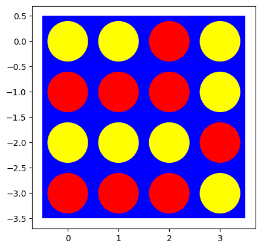

```
{-1: 0, 1: 0, 'd': 1}
```

```
CPU times: user 531 ms, sys: 97.2 ms, total: 628 ms
Wall time: 658 ms
```

```python
# Your code/ answer goes here.
%time display(agent_play_heuistic(N=1))
```

Running at cutoff = 10.

```python
class Heu_Agent:
    def __init__(self, initial_state, player , name = "An Agent"):
        self.state = initial_state # this is the state of the agent
        self.player = player
        self.name = name

    def act(self, state, cutoff=10):
        #print("    ", self.name, ": My state is", self.state, "and I am going to make a move.")
        action = alpha_beta_search(state,cutoff, self.player)
        self.state = result(state, self.player, action['move'][0], action['move'][1])

        print("    ", self.name, ": I play move [", action['move'][0], "", action['move'][1], "].")

        return action
```

```python
%time display(agent_play_heuistic(N=1))
```

```
Number of nodes searched (cutoff = 10): 4216
     red agent : I play move [ 3  0 ].
Number of nodes searched (cutoff = 10): 4477
     yellow agent : I play move [ 2  0 ].
Number of nodes searched (cutoff = 10): 9149
     red agent : I play move [ 1  0 ].
Number of nodes searched (cutoff = 10): 2011
     yellow agent : I play move [ 0  0 ].
Number of nodes searched (cutoff = 10): 2326
     red agent : I play move [ 3  1 ].
Number of nodes searched (cutoff = 10): 1961
     yellow agent : I play move [ 3  3 ].
Number of nodes searched (cutoff = 10): 820
     red agent : I play move [ 3  2 ].
Number of nodes searched (cutoff = 10): 575
     yellow agent : I play move [ 2  1 ].
Number of nodes searched (cutoff = 10): 208
     red agent : I play move [ 1  1 ].
Number of nodes searched (cutoff = 10): 141
     yellow agent : I play move [ 0  1 ].
Number of nodes searched (cutoff = 10): 33
     red agent : I play move [ 2  2 ].
Number of nodes searched (cutoff = 10): 16
     yellow agent : I play move [ 1  2 ].
Number of nodes searched (cutoff = 10): 9
     red agent : I play move [ 0  2 ].
Number of nodes searched (cutoff = 10): 4
     yellow agent : I play move [ 2  3 ].
Number of nodes searched (cutoff = 10): 3
     red agent : I play move [ 1  3 ].
Number of nodes searched (cutoff = 10): 2
     yellow agent : I play move [ 0  3 ].
```

```
{-1: 0, 1: 0, 'd': 1}
```

```
CPU times: user 2.85 s, sys: 190 ms, total: 3.04 s
Wall time: 2.92 s
```

Running at cutoff = 20.

```python
class Heu_Agent:
    def __init__(self, initial_state, player , name = "An Agent"):
        self.state = initial_state # this is the state of the agent
        self.player = player
        self.name = name

    def act(self, state, cutoff=20):
        #print("    ", self.name, ": My state is", self.state, "and I am going to make a move.")
        action = alpha_beta_search(state,cutoff, self.player)
        self.state = result(state, self.player, action['move'][0], action['move'][1])

        print("    ", self.name, ": I play move [", action['move'][0], "", action['move'][1], "].")

        return action
```

```python
%time display(agent_play_heuistic(N=1))
```

```
Number of nodes searched (cutoff = 20): 62889
     red agent : I play move [ 3  0 ].
Number of nodes searched (cutoff = 20): 32379
     yellow agent : I play move [ 2  0 ].
Number of nodes searched (cutoff = 20): 27522
     red agent : I play move [ 1  0 ].
Number of nodes searched (cutoff = 20): 10597
     yellow agent : I play move [ 0  0 ].
Number of nodes searched (cutoff = 20): 2463
     red agent : I play move [ 3  1 ].
Number of nodes searched (cutoff = 20): 1439
     yellow agent : I play move [ 2  1 ].
Number of nodes searched (cutoff = 20): 811
     red agent : I play move [ 1  1 ].
Number of nodes searched (cutoff = 20): 314
     yellow agent : I play move [ 0  1 ].
Number of nodes searched (cutoff = 20): 91
     red agent : I play move [ 3  2 ].
Number of nodes searched (cutoff = 20): 50
     yellow agent : I play move [ 3  3 ].
Number of nodes searched (cutoff = 20): 33
     red agent : I play move [ 2  2 ].
Number of nodes searched (cutoff = 20): 16
     yellow agent : I play move [ 1  2 ].
Number of nodes searched (cutoff = 20): 9
     red agent : I play move [ 0  2 ].
Number of nodes searched (cutoff = 20): 4
     yellow agent : I play move [ 2  3 ].
Number of nodes searched (cutoff = 20): 3
     red agent : I play move [ 1  3 ].
Number of nodes searched (cutoff = 20): 2
     yellow agent : I play move [ 0  3 ].
```

```
{-1: 0, 1: 0, 'd': 1}
```

```
CPU times: user 15 s, sys: 740 ms, total: 15.7 s
Wall time: 15.3 s
```

I am going to choose to stick with cutoff = 10. I didn't see a lot of improvement but after getting to 20 it did start to take longer again and if the improvements aren't lofty then I'd rather keep it short.

```python
class Heu_Agent:
    def __init__(self, initial_state, player , name = "An Agent"):
        self.state = initial_state # this is the state of the agent
        self.player = player
        self.name = name

    def act(self, state, cutoff=10):
        #print("    ", self.name, ": My state is", self.state, "and I am going to make a move.")
        action = alpha_beta_search(state,cutoff, self.player)
        self.state = result(state, self.player, action['move'][0], action['move'][1])

        print("    ", self.name, ": I play move [", action['move'][0], "", action['move'][1], "].")

        return action
```

Experiment with the same manually created boards as above to check if the agent spots wining opportunities.

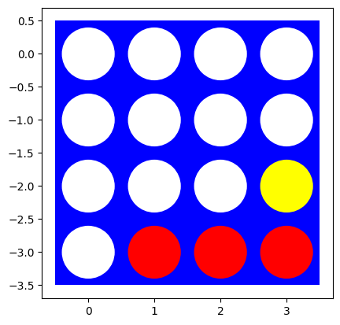

```python
visualize(board1)
```

```
Number of nodes searched (cutoff = 10): 760
     red agent : I play move [ 3  0 ].
```

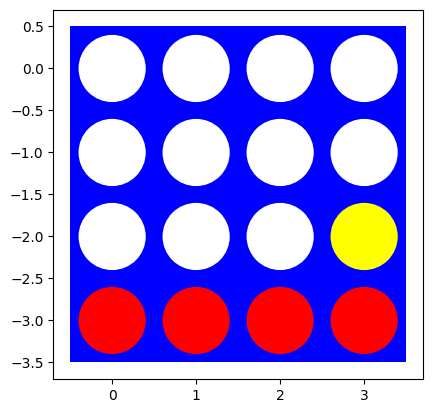

```
{-1: 0, 1: 1, 'd': 0}
```

```
CPU times: user 368 ms, sys: 104 ms, total: 472 ms
Wall time: 376 ms
```

```python
%time display(agent_play_heuistic(N=1, board = board1))
```

[figure not shown]

```python
visualize(board2)
```

```
Number of nodes searched (cutoff = 10): 8
     red agent : I play move [ 0  0 ].
```

[figure not shown]

```
{-1: 0, 1: 1, 'd': 0}
```

```
CPU times: user 285 ms, sys: 82.5 ms, total: 368 ms
Wall time: 273 ms
```

```python
%time display(agent_play_heuistic(N=1, board = board2))
```

[figure not shown]

```python
visualize(board3)
```

```
Number of nodes searched (cutoff = 10): 141
     red agent : I play move [ 0  0 ].
Number of nodes searched (cutoff = 10): 12
     yellow agent : I play move [ 1  1 ].
```

[figure not shown]

```
{-1: 1, 1: 0, 'd': 0}
```

```
CPU times: user 311 ms, sys: 112 ms, total: 423 ms
Wall time: 338 ms
```

```python
%time display(agent_play_heuistic(N=1, board = board3))
```

[figure not shown]

```python
visualize(board4)
```

```
Number of nodes searched (cutoff = 10): 92
     red agent : I play move [ 1  2 ].
```

[figure not shown]

```
{-1: 0, 1: 1, 'd': 0}
```

```
CPU times: user 398 ms, sys: 89 ms, total: 487 ms
Wall time: 409 ms
```

```python
%time display(agent_play_heuistic(N=1, board = board4))
```

[figure not shown]

```python
visualize(board5)
```

```
Number of nodes searched (cutoff = 10): 29600
     red agent : I play move [ 0  0 ].
Number of nodes searched (cutoff = 10): 770
     yellow agent : I play move [ 1  1 ].
Number of nodes searched (cutoff = 10): 101
     red agent : I play move [ 0  1 ].
Number of nodes searched (cutoff = 10): 88
     yellow agent : I play move [ 1  2 ].
```

[figure not shown]

```
{-1: 1, 1: 0, 'd': 0}
```

```
CPU times: user 7.71 s, sys: 294 ms, total: 8.01 s
Wall time: 7.84 s
```

```python
%time display(agent_play_heuistic(N=1, board = board5))
```

How long does it take to make a move? Start with a smaller board with 4 columns and make the board larger by adding columns.

```python
# Your code/ answer goes here.
board4x4 = empty_board(shape=(4,4))
agent_red = Heu_Agent(board4x4, 1, name = 'red agent')
%time display(agent_red.act(board4x4))
```

```
Number of nodes searched (cutoff = 10): 4216
     red agent : I play move [ 3  0 ].
```

```
{'move': [3, 0], 'value': 0.0}
```

```
CPU times: user 490 ms, sys: 33.5 ms, total: 523 ms
Wall time: 504 ms
```

```python
# Your code/ answer goes here.
board4x5 = empty_board(shape=(4,5))
agent_red = Heu_Agent(board4x5, 1, name = 'red agent')
%time display(agent_red.act(board4x5))
```

```
Number of nodes searched (cutoff = 10): 22599
     red agent : I play move [ 3  0 ].
```

```
{'move': [3, 0], 'value': 0.0}
```

```
CPU times: user 2.53 s, sys: 124 ms, total: 2.66 s
Wall time: 2.58 s
```

```python
board4x6 = empty_board(shape=(4,6))
agent_red = Heu_Agent(board4x6, 1, name = 'red agent')
%time display(agent_red.act(board4x6))
```

```
Number of nodes searched (cutoff = 10): 102370
     red agent : I play move [ 3  0 ].
```

```
{'move': [3, 0], 'value': 0.0}
```

```
CPU times: user 12.4 s, sys: 398 ms, total: 12.8 s
Wall time: 12.5 s
```

The Heuristic agent is much faster at making decisions than the Minimax.

### Playtime [5 points]

Let two heuristic search agents (different cutoff depth, different heuristic evaluation function) compete against each other on a reasonably sized board. Since there is no randomness, you only need to let them play once.

```python
# Your code/ answer goes here.
def eval_fun1(state, player):
    """heuristic for utility of state. Returns score for a node:
    This is for the agent with the vertical + horizontal

    Function Returns: heuistic value, terminal?"""

    # terminal state?
    u = utility(state, player)
    if u is not None: return u, True

    score = 0
    weight = 1 / (len(state) + len(state[0]))

    for row in range(len(state)):
      for column in range(len(state[0])):
        if state[row][column] == player:
          score = score + weight * check_horizontal_count(state, row, column)
          score = score + weight * check_vertical_count(state, row, column)
          #score = score + weight * check_diagonal_count(state, row, column)
    return score, False
```

```python
import math

# Your code/ answer goes here.
# global variables
DEBUG = 1 # 1 ... count nodes, 2 ... debug each node
COUNT = 0

def alpha_beta_search1(board, cutoff = None, player = 1):
    """start the search. cutoff = None is minimax search with alpha-beta pruning."""
    global DEBUG, COUNT
    COUNT = 0

    value, move = max_value_ab(board, player, -math.inf, +math.inf, 0, cutoff)

    if DEBUG >= 1: print(f"Number of nodes searched (cutoff = {cutoff}): {COUNT}")

    return {"move": move, "value": value}

def max_value_ab(state, player, alpha, beta, depth, cutoff):
    """player's best move."""
    global DEBUG, COUNT
    COUNT += 1

    # cut off and terminal test
    v, terminal = eval_fun1(state, player)
    if((cutoff is not None and depth >= cutoff) or terminal):
        if(terminal):
            alpha, beta = v, v
        if DEBUG >= 2: print(f"stopped at {depth}: {state} term: {terminal} eval: {v} [{alpha}, {beta}]" )
        return v, None

    v, move = -math.inf, None

    # check all possible actions in the state, update alpha and return move with the largest value
    for a in check_actions(state):
        v2, a2 = min_value_ab(result(state, player, a[0], a[1]), player, alpha, beta, depth + 1, cutoff)
        if v2 > v:
            v, move = v2, a
            alpha = max(alpha, v)
        if v >= beta: return v, move

    return v, move

def min_value_ab(state, player, alpha, beta, depth, cutoff):
    """opponent's best response."""
    global DEBUG, COUNT
    COUNT += 1

    # cut off and terminal test
    v, terminal = eval_fun1(state, player)
    if((cutoff is not None and depth >= cutoff) or terminal):
        if(terminal):
            alpha, beta = v, v
        if DEBUG >= 2: print(f"stopped at {depth}: {state} term: {terminal} eval: {v} [{alpha}, {beta}]" )
        return v, None

    v, move = +math.inf, None

    # check all possible actions in the state, update beta and return move with the smallest value
    for a in check_actions(state):
        v2, a2 = max_value_ab(result(state, other(player), a[0], a[1]), player, alpha, beta, depth + 1, cutoff)
        if v2 < v:
            v, move = v2, a
            beta = min(beta, v)
        if v <= alpha: return v, move

    return v, move
```

```python
class Heu_Agent1:
    def __init__(self, initial_state, player , name = "An Agent"):
        self.state = initial_state # this is the state of the agent
        self.player = player
        self.name = name

    def act(self, state, cutoff=10):
        #print("    ", self.name, ": My state is", self.state, "and I am going to make a move.")
        action = alpha_beta_search1(state,cutoff, self.player)
        self.state = result(state, self.player, action['move'][0], action['move'][1])

        print("    ", self.name, ": I play move [", action['move'][0], "", action['move'][1], "].")

        return action
```

```python
# Your code/ answer goes here.
def eval_fun2(state, player):
    """heuristic for utility of state. Returns score for a node:
    This is for the agent with the vertical + horizontal

    Function Returns: heuistic value, terminal?"""

    # terminal state?
    u = utility(state, player)
    if u is not None: return u, True

    score = 0
    weight = 1 / (len(state) + len(state[0]) - 7)

    for row in range(len(state)):
      for column in range(len(state[0])):
        if state[row][column] == player:
          #score = score + weight * check_horizontal_count(state, row, column)
          #score = score + weight * check_vertical_count(state, row, column)
          score = score + weight * check_diagonal_count(state, row, column)
    return score, False
```

```python
import math

# Your code/ answer goes here.
# global variables
DEBUG = 1 # 1 ... count nodes, 2 ... debug each node
COUNT = 0

def alpha_beta_search2(board, cutoff = None, player = 1):
    """start the search. cutoff = None is minimax search with alpha-beta pruning."""
    global DEBUG, COUNT
    COUNT = 0

    value, move = max_value_ab(board, player, -math.inf, +math.inf, 0, cutoff)

    if DEBUG >= 1: print(f"Number of nodes searched (cutoff = {cutoff}): {COUNT}")

    return {"move": move, "value": value}

def max_value_ab(state, player, alpha, beta, depth, cutoff):
    """player's best move."""
    global DEBUG, COUNT
    COUNT += 1

    # cut off and terminal test
    v, terminal = eval_fun2(state, player)
    if((cutoff is not None and depth >= cutoff) or terminal):
        if(terminal):
            alpha, beta = v, v
        if DEBUG >= 2: print(f"stopped at {depth}: {state} term: {terminal} eval: {v} [{alpha}, {beta}]" )
        return v, None

    v, move = -math.inf, None

    # check all possible actions in the state, update alpha and return move with the largest value
    for a in check_actions(state):
        v2, a2 = min_value_ab(result(state, player, a[0], a[1]), player, alpha, beta, depth + 1, cutoff)
        if v2 > v:
            v, move = v2, a
            alpha = max(alpha, v)
        if v >= beta: return v, move

    return v, move

def min_value_ab(state, player, alpha, beta, depth, cutoff):
    """opponent's best response."""
    global DEBUG, COUNT
    COUNT += 1

    # cut off and terminal test
    v, terminal = eval_fun2(state, player)
    if((cutoff is not None and depth >= cutoff) or terminal):
        if(terminal):
            alpha, beta = v, v
        if DEBUG >= 2: print(f"stopped at {depth}: {state} term: {terminal} eval: {v} [{alpha}, {beta}]" )
        return v, None

    v, move = +math.inf, None

    # check all possible actions in the state, update beta and return move with the smallest value
    for a in check_actions(state):
        v2, a2 = max_value_ab(result(state, other(player), a[0], a[1]), player, alpha, beta, depth + 1, cutoff)
        if v2 < v:
            v, move = v2, a
            beta = min(beta, v)
        if v <= alpha: return v, move

    return v, move
```

```python
class Heu_Agent2:
    def __init__(self, initial_state, player , name = "An Agent"):
        self.state = initial_state # this is the state of the agent
        self.player = player
        self.name = name

    def act(self, state, cutoff=10):
        #print("    ", self.name, ": My state is", self.state, "and I am going to make a move.")
        action = alpha_beta_search2(state,cutoff, self.player)
        self.state = result(state, self.player, action['move'][0], action['move'][1])

        print("    ", self.name, ": I play move [", action['move'][0], "", action['move'][1], "].")

        return action
```

```python
def agent_play_heuistic(N = 1, board=empty_board(shape=(6,6))):
  results = {-1: 0, 1: 0, 'd': 0}
  state = np.copy(board)
  for i in range(N):
    board = np.copy(state)
    agent_red = Heu_Agent1(board, 1, name = 'red vert and horizontal agent')
    agent_yellow = Heu_Agent2(board, -1, name = 'yellow diagonal agent')
    active_player = agent_red
    while True:
      action = active_player.act(board)
      board = result(board, active_player.player, action['move'][0], action['move'][1])

      win = terminal_checks(board)
      if win != 'n':
        visualize(board)
        results[win] += 1
        break

      if active_player.player == 1:
        active_player = agent_yellow
      else:
        active_player = agent_red
  return results
```

```
Number of nodes searched (cutoff = 10): 64447
     red vert and horizontal agent : I play move [ 5  0 ].
Number of nodes searched (cutoff = 10): 43894
     yellow diagonal agent : I play move [ 4  0 ].
Number of nodes searched (cutoff = 10): 66106
     red vert and horizontal agent : I play move [ 3  0 ].
Number of nodes searched (cutoff = 10): 43166
     yellow diagonal agent : I play move [ 2  0 ].
Number of nodes searched (cutoff = 10): 68106
     red vert and horizontal agent : I play move [ 1  0 ].
Number of nodes searched (cutoff = 10): 94137
     yellow diagonal agent : I play move [ 0  0 ].
Number of nodes searched (cutoff = 10): 23704
     red vert and horizontal agent : I play move [ 5  1 ].
Number of nodes searched (cutoff = 10): 36836
     yellow diagonal agent : I play move [ 4  1 ].
Number of nodes searched (cutoff = 10): 33082
     red vert and horizontal agent : I play move [ 3  1 ].
Number of nodes searched (cutoff = 10): 14109
     yellow diagonal agent : I play move [ 2  1 ].
Number of nodes searched (cutoff = 10): 21343
     red vert and horizontal agent : I play move [ 1  1 ].
Number of nodes searched (cutoff = 10): 15204
     yellow diagonal agent : I play move [ 5  2 ].
Number of nodes searched (cutoff = 10): 13514
     red vert and horizontal agent : I play move [ 0  1 ].
Number of nodes searched (cutoff = 10): 18496
     yellow diagonal agent : I play move [ 5  4 ].
Number of nodes searched (cutoff = 10): 13620
     red vert and horizontal agent : I play move [ 4  2 ].
Number of nodes searched (cutoff = 10): 21153
     yellow diagonal agent : I play move [ 5  5 ].
Number of nodes searched (cutoff = 10): 4822
     red vert and horizontal agent : I play move [ 5  3 ].
Number of nodes searched (cutoff = 10): 4453
     yellow diagonal agent : I play move [ 3  2 ].
Number of nodes searched (cutoff = 10): 5735
     red vert and horizontal agent : I play move [ 4  3 ].
Number of nodes searched (cutoff = 10): 4931
     yellow diagonal agent : I play move [ 2  2 ].
Number of nodes searched (cutoff = 10): 3450
     red vert and horizontal agent : I play move [ 4  4 ].
Number of nodes searched (cutoff = 10): 4491
     yellow diagonal agent : I play move [ 4  5 ].
Number of nodes searched (cutoff = 10): 2424
     red vert and horizontal agent : I play move [ 3  4 ].
Number of nodes searched (cutoff = 10): 1342
     yellow diagonal agent : I play move [ 1  2 ].
Number of nodes searched (cutoff = 10): 521
     red vert and horizontal agent : I play move [ 0  2 ].
Number of nodes searched (cutoff = 10): 541
     yellow diagonal agent : I play move [ 2  4 ].
Number of nodes searched (cutoff = 10): 326
     red vert and horizontal agent : I play move [ 3  3 ].
Number of nodes searched (cutoff = 10): 6
     yellow diagonal agent : I play move [ 2  3 ].
```

[figure not shown]

```
{-1: 1, 1: 0, 'd': 0}
```

```
CPU times: user 1min 36s, sys: 3 s, total: 1min 39s
Wall time: 1min 38s
```

```python
%time display(agent_play_heuistic())
```

## Challenge task [up to +10 bonus point will be awarded separately]

Find another student and let your best agent play against the other student's best player. We will set up a class tournament on Canvas. This tournament will continue after the submission deadline.

## Graduate student advanced task: Pure Monte Carlo Search and Best First Move [10 point]

**Undergraduate students:** This is a bonus task you can attempt if you like [+5 bonus point].

### Pure Monte Carlo Search

Implement Pure Monte Carlo Search and investigate how this search performs on the test boards that you have used above.

```python
# Your code/ answer goes here.
import random

def playout(state, action, player = 1):
    """Perfrom a random playout starting with the given action on the fiven board
    and return the utility of the finished game."""
    state = result(state, player, action[0], action[1])
    current_player = other(player)

    while(True):
        # reached terminal state?
        u = utility(state, player)
        if u is not None:
            return u

        # we use a random playout policy
        actions = check_actions(state)
        random_selector = random.randint(0, len(actions) - 1)
        a = actions[random_selector]
        state = result(state, current_player, a[0], a[1])
        #print(state)

        # switch between players
        current_player = other(current_player)


board = empty_board()
display([ playout(board, [5,0]) for i in range(20) ])
```

```
[1, -1, 1, 1, -1, 1, 1, 1, 1, 1, 1, 1, -1, 1, 1, 1, -1, -1, -1, -1]
```

```python
def playouts(board, action, player = 1, N = 100):
    """Perform N playouts following the given action for the given board."""
    return [ playout(board, action, player) for i in range(N) ]
u = playouts(board, [5,0])
print("Playout results:", u)
```

```
Playout results: [1, -1, -1, 1, 1, 1, -1, -1, 1, -1, -1, -1, 1, 1, 1, -1, -1, 1, 1, -1, 1, 1, 1, 1, -1, -1, 1, -1, -1, -1, 1, 1, 1, 1, 1, 1, 1, 1, 1, -1, -1, 1, -1, 1, 1, -1, -1, -1, -1, 1, 1, 1, 1, -1, 1, -1, 1, -1, -1, -1, 1, -1, -1, 1, -1, 1, -1, 1, -1, 1, -1, 1, 1, 1, 1, 1, -1, -1, 1, 1, -1, 1, …
```

```python
import math
DEBUG = 1


def pmcs(board, N = 100, player = 1):
    """Pure Monte Carlo Search. Returns the action that has the largest average utility.
    The N playouts are evenly divided between the possible actions."""
    global DEBUG

    acts = check_actions(board)
    n = math.floor(N/len(acts))
    if DEBUG >= 1: print(f"Actions: {acts} ({N} total playouts = {n} playouts per action)")

    ps = { i : np.mean(playouts(board, acts[i], player, N = n)) for i in range(len(acts)) }
    if DEBUG >= 1: display(ps)

    action = max(ps, key=ps.get)
    return action

board = empty_board()
display(board)
%time print(pmcs(board))

print()
print("1000 playouts give a better utility estimate.")
%time print(pmcs(board, N = 1000))
```

```
array([[0, 0, 0, 0, 0, 0, 0],
       [0, 0, 0, 0, 0, 0, 0],
       [0, 0, 0, 0, 0, 0, 0],
       [0, 0, 0, 0, 0, 0, 0],
       [0, 0, 0, 0, 0, 0, 0],
       [0, 0, 0, 0, 0, 0, 0]])
```

```
Actions: [[5, 0], [5, 1], [5, 2], [5, 3], [5, 4], [5, 5], [5, 6]] (100 total playouts = 14 playouts per action)
```

```
{0: 0.14285714285714285,
 1: 0.2857142857142857,
 2: 0.42857142857142855,
 3: 0.14285714285714285,
 4: 0.5714285714285714,
 5: -0.07142857142857142,
 6: 0.14285714285714285}
```

```
4
CPU times: user 263 ms, sys: 11 ms, total: 274 ms
Wall time: 274 ms

1000 playouts give a better utility estimate.
Actions: [[5, 0], [5, 1], [5, 2], [5, 3], [5, 4], [5, 5], [5, 6]] (1000 total playouts = 142 playouts per action)
```

```
{0: 0.06338028169014084,
 1: -0.056338028169014086,
 2: 0.2676056338028169,
 3: 0.19718309859154928,
 4: 0.2112676056338028,
 5: 0.2112676056338028,
 6: -0.028169014084507043}
```

```
2
CPU times: user 2.43 s, sys: 96.5 ms, total: 2.53 s
Wall time: 2.46 s
```

```python
board = empty_board()
z = pmcs(board)
z
```

```
Actions: [[5, 0], [5, 1], [5, 2], [5, 3], [5, 4], [5, 5], [5, 6]] (100 total playouts = 14 playouts per action)
```

```
{0: -0.2857142857142857,
 1: 0.2857142857142857,
 2: -0.42857142857142855,
 3: 0.2857142857142857,
 4: 0.14285714285714285,
 5: 0.2857142857142857,
 6: 0.0}
```

```
1
```

```python
z
```

```
1
```

```python
def play(N = 100, board=empty_board(shape=(4,4))):
    results = {-1: 0, 1: 0, 'd': 0}
    state = np.copy(board)
    for i in range(N):
      board = np.copy(state)
      active_player = 1

      while True:
        acts = check_actions(board)
        action = pmcs(board, N = 100, player=active_player)
        board = result(board, active_player, acts[action][0], acts[action][1])
        if DEBUG >= 1: print(f"Player {active_player} uses action {acts[action]}")

        win = terminal_checks(board)
        if win != 'n':
            if DEBUG >= 1: print(f"Result {board} winner: {win}")
            visualize(board)
            results[win] += 1
            break

        active_player = switch_player(active_player)

    return results
```

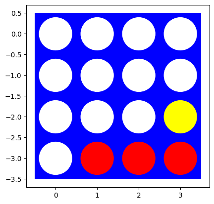

```python
visualize(board1)
```

```
Number of nodes searched (cutoff = 10): 760
     red vert and horizontal agent : I play move [ 3  0 ].
```

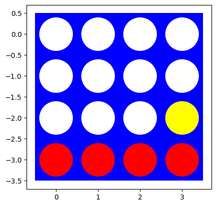

```
{-1: 0, 1: 1, 'd': 0}
```

```
CPU times: user 353 ms, sys: 103 ms, total: 456 ms
Wall time: 355 ms
```

```python
%time display(agent_play_heuistic(N=1, board = board1))
```

[figure not shown]

```python
visualize(board2)
```

```
Number of nodes searched (cutoff = 10): 8
     red vert and horizontal agent : I play move [ 0  0 ].
```

[figure not shown]

```
{-1: 0, 1: 1, 'd': 0}
```

```
CPU times: user 271 ms, sys: 110 ms, total: 381 ms
Wall time: 288 ms
```

```python
%time display(agent_play_heuistic(N=1, board = board2))
```

[figure not shown]

```python
visualize(board3)
```

```
Number of nodes searched (cutoff = 10): 141
     red vert and horizontal agent : I play move [ 0  0 ].
Number of nodes searched (cutoff = 10): 12
     yellow diagonal agent : I play move [ 1  1 ].
```

[figure not shown]

```
{-1: 1, 1: 0, 'd': 0}
```

```
CPU times: user 308 ms, sys: 98.9 ms, total: 407 ms
Wall time: 314 ms
```

```python
%time display(agent_play_heuistic(N=1, board = board3))
```

[figure not shown]

```python
visualize(board4)
```

```
Number of nodes searched (cutoff = 10): 92
     red vert and horizontal agent : I play move [ 1  2 ].
```

[figure not shown]

```
{-1: 0, 1: 1, 'd': 0}
```

```
CPU times: user 392 ms, sys: 109 ms, total: 501 ms
Wall time: 404 ms
```

```python
%time display(agent_play_heuistic(N=1, board = board4))
```

[figure not shown]

```python
visualize(board5)
```

```
Number of nodes searched (cutoff = 10): 29371
     red vert and horizontal agent : I play move [ 0  0 ].
Number of nodes searched (cutoff = 10): 770
     yellow diagonal agent : I play move [ 1  1 ].
Number of nodes searched (cutoff = 10): 101
     red vert and horizontal agent : I play move [ 0  1 ].
Number of nodes searched (cutoff = 10): 88
     yellow diagonal agent : I play move [ 1  2 ].
```

[figure not shown]

```
{-1: 1, 1: 0, 'd': 0}
```

```
CPU times: user 6.39 s, sys: 223 ms, total: 6.61 s
Wall time: 6.52 s
```

```python
%time display(agent_play_heuistic(N=1, board = board5))
```

### Best First Move

Use Oure Monte Carlo Search to determine what the best first move is? Describe under what assumptions this is the "best" first move.

```python
# Your code/ answer goes here.
board = empty_board()
print()
%time display(pmcs(board, N = 1000))
```

```
Actions: [[5, 0], [5, 1], [5, 2], [5, 3], [5, 4], [5, 5], [5, 6]] (1000 total playouts = 142 playouts per action)
```

```
{0: -0.04225352112676056,
 1: 0.09859154929577464,
 2: 0.23943661971830985,
 3: 0.24647887323943662,
 4: 0.16901408450704225,
 5: 0.2112676056338028,
 6: 0.1267605633802817}
```

```
3
```

```
CPU times: user 2.13 s, sys: 91.2 ms, total: 2.22 s
Wall time: 2.17 s
```

```python
# Code and description go here
!pip install nbconvert

from google.colab import drive
drive.mount('/content/drive')
!jupyter nbconvert --to html /content/drive/MyDrive/Colab\ Notebooks/assignment_connect4.ipynb
```